# Week 8 · Explore patterns without overstating them

MATH 346 course companion · R

**Note**

Use this chapter with the companion reading guide. **Nothing in this chapter is collected or graded.** The approved syllabus, workload guide and Blackboard remain authoritative.

## Your route

**What does a plot show, what remains uncertain, and which check comes next?**

Exploration moves between a question, a checked summary or plot, and a more precise question. The built-in diamonds data provide 53,940 observations with prices, carat weights, ordered quality grades and recorded dimensions.

A clean-looking plot is not a final explanation. We distinguish missing values from implausible recorded values, compare distribution views, and examine what can be hidden in a dense scatterplot or a marginal group comparison.

Before you start · Words used here · Setup · Meeting 1 · Meeting 2 · AI audit · Practice and resources · Chapter list. The page contents navigation also links to the sections.

**TipA first 30-minute recovery session**

Choose a stopping point within about 30 minutes; continue from there next time. This is an untested first-pass budget, not a completion promise.

1. Check prerequisites and setup. If access is blocked, focus on that first.
2. Read the structure audit and distinguish no missing values from plausible recorded dimensions.
3. Inspect a histogram and the transparent carat-price scatterplot; locate the row-count checks.
4. Try the second self-check and choose one Core 3/6 display comparison to continue.

Read displayed results when jumping ahead; run complete code in its stated sequence when returning to your script. The full practice selection is Core **1, 2, 3, 6, 9**, selective Guided **4, 5, 7**, and optional Extension **8**, within the **90–120-minute** ordinary-week budget.

### Before you start

You should recognize variables, grouped counts and ggplot layers from Weeks 6–7. No file import, regression or causal method is assumed. Use the Week 6/7 recovery companions if plot mappings or row accounting remain unclear.

Use [software requirements](https://lnajman.github.io/math346/resources/software-requirements.html) and the [course glossary](https://lnajman.github.io/math346/resources/glossary.html) when needed. You do not need a paid AI account or an external AI call: the flawed examples are supplied locally.

**NoteWords used in this chapter**

| Word or pattern | Meaning here |
| --- | --- |
| **Distribution** | How values of one variable are spread across observations. |
| **Bin width** | The interval size used to group numeric values in a histogram. |
| **Covariation** | How two variables vary together. |
| **Overplotting** | Points cover one another, hiding density or variation. |
| **Marginal comparison** | Compare groups without holding related variables similar. |
| **Conditional view** | Examine a relationship within a category or a stated range. |
| **Anomaly** | An unusual value needing investigation; it is not automatically an error. |
| **Sensitivity check** | Compare a result under an explicit alternative handling of a concern. |
| **EDA log** | A record of question, evidence, pattern/anomaly, limitation and next question. |

### Read / Explain / Check / Interpret

Read the inputs and operations; explain your prediction; check a specific claim; interpret the result with its domain or units.

Think first; write a private comment only where requested—see the prediction guide.

## Setup

Use the dplyr and ggplot2 packages. The data are built into ggplot2; no CSV is needed. Save both starters in a `week08` folder.

Download the starters first. Keep these files in your working folder: `week08-eda-cycle.R`; `week08-plot-checks.R`.

Possible solutions are separate comparison files linked below.

- Starter: week08-eda-cycle.R
- Starter: week08-plot-checks.R
- AI critique target: week08-ai-interpretation-review.R

Run this before the other blocks; it reports missing paths without changing files.

```r
required_paths <- c("week08-eda-cycle.R", "week08-plot-checks.R")
```

```r
missing_paths <- required_paths[!file.exists(required_paths)]
if (length(missing_paths) == 0) {
  cat("Setup OK\n")
} else {
  cat("Missing from the current folder:\n", paste(missing_paths, collapse = "\n"), "\n", sep = "")
}
```

**Example output when all required files are present:**

```
Setup OK
```

This is example output, not confirmation of your computer’s setup. Run the check in your own R session and read that result. Restart R, then run the chapter’s code in order, including the code inside the reference reveals. A successful `stopifnot` is silent; a failed condition stops the script.

## Meeting 1 · Read the computation

Class route: two 75-minute meetings, each with its final five-minute exit.

First match variable types to questions: prices and carat are numeric; cut is an ordered category. A histogram groups price values into intervals; a bar chart counts categories. State units before plotting. No NA in the file means no explicitly missing values, not that all measurements are physically plausible. Keep unusual records available for investigation.

### Structure, distributions and questions

**Slide cues:** *Start With An Audit*; *No `NA` Does Not Mean Clean*; *Histogram Pattern*; *Validate Histogram Counts*.

The reference keeps `diamonds_raw`, then adds a logical dimension flag. It prints a structure audit, price summary, cut counts, grouped medians and anomaly table before interpreting the plots. Read the OR condition literally: a row is flagged if any one of x, y or z is nonpositive; it is counted once even if several dimensions are affected.

For the price histogram, the $500 bin width is stated in code and caption. Changing the bin width changes displayed detail without changing the dataset. The mean exceeds the median and the distribution is right-skewed; describe the observed shape rather than asserting a probability model.

**Predict in a private comment first:** Can there be 20 dimension concerns when the missing-value count is zero? Would changing histogram bin width change the number of input diamonds?

**Compare your reasoning**

Yes: zeros are recorded numbers, not NA. Twenty rows contain at least one nonpositive dimension. Changing bin width changes grouping of the same prices, not the number of input observations. If your answer differed, separate missing encodings from plausibility and distinguish a display choice from filtering.

**Try before expanding:** Use Core 1/2/3 to classify variables, inspect the audit and choose bin widths before comparing the reference. Keep an EDA-log entry with a limitation as well as a pattern.

**Reference version · week08-eda-cycle_sol.R**

```r
# MATH 346 - possible worked solution
# Compare only after attempting the starter; other correct implementations are possible.

# MATH 346 - Week 8
# A checked exploratory data analysis cycle using ggplot2::diamonds

library(dplyr)
library(ggplot2)

diamonds_raw <- diamonds |> as_tibble()

diamonds_eda <- diamonds_raw |>
  mutate(
    dimension_issue = x <= 0 | y <= 0 | z <= 0
  )

structure_audit <- data.frame(
  quantity = c(
    "rows",
    "original variables",
    "missing values",
    "rows with a nonpositive dimension"
  ),
  value = c(
    nrow(diamonds_eda),
    ncol(diamonds_raw),
    sum(is.na(diamonds_raw)),
    sum(diamonds_eda$dimension_issue)
  )
)

price_summary <- diamonds_eda |>
  summarize(
    n = n(),
    minimum_usd = min(price),
    first_quartile_usd = quantile(price, 0.25),
    median_usd = median(price),
    mean_usd = mean(price),
    third_quartile_usd = quantile(price, 0.75),
    maximum_usd = max(price)
  )

cut_summary <- diamonds_eda |>
  count(cut, name = "n_diamonds") |>
  mutate(proportion = n_diamonds / sum(n_diamonds))

price_by_cut <- diamonds_eda |>
  group_by(cut) |>
  summarize(
    n_diamonds = n(),
    median_carat = median(carat),
    median_price_usd = median(price),
    .groups = "drop"
  )

dimension_issues <- diamonds_eda |>
  filter(dimension_issue) |>
  select(carat, price, cut, x, y, z)

print(structure_audit)
```

```
                           quantity value
1                              rows 53940
2                original variables    10
3                    missing values     0
4 rows with a nonpositive dimension    20
```

```r
print(price_summary)
```

```
# A tibble: 1 × 7
      n minimum_usd first_quartile_usd median_usd mean_usd third_quartile_usd
  <int>       <int>              <dbl>      <dbl>    <dbl>              <dbl>
1 53940         326                950       2401    3933.              5324.
# ℹ 1 more variable: maximum_usd <int>
```

```r
print(cut_summary)
```

```
# A tibble: 5 × 3
  cut       n_diamonds proportion
  <ord>          <int>      <dbl>
1 Fair            1610     0.0298
2 Good            4906     0.0910
3 Very Good      12082     0.224
4 Premium        13791     0.256
5 Ideal          21551     0.400
```

```r
print(price_by_cut)
```

```
# A tibble: 5 × 4
  cut       n_diamonds median_carat median_price_usd
  <ord>          <int>        <dbl>            <dbl>
1 Fair            1610         1               3282
2 Good            4906         0.82            3050.
3 Very Good      12082         0.71            2648
4 Premium        13791         0.86            3185
5 Ideal          21551         0.54            1810
```

```r
print(dimension_issues)
```

```
# A tibble: 20 × 6
   carat price cut           x     y     z
   <dbl> <int> <ord>     <dbl> <dbl> <dbl>
 1  1     3142 Premium    6.55  6.48     0
 2  1.01  3167 Premium    6.66  6.6      0
 3  1.1   3696 Premium    6.5   6.47     0
 4  1.01  3837 Premium    6.5   6.47     0
 5  1.5   4731 Good       7.15  7.04     0
 6  1.07  4954 Ideal      0     6.62     0
 7  1     5139 Very Good  0     0        0
 8  1.15  5564 Ideal      6.88  6.83     0
 9  1.14  6381 Fair       0     0        0
10  2.18 12631 Premium    8.49  8.45     0
11  1.56 12800 Ideal      0     0        0
12  2.25 15397 Premium    8.52  8.42     0
13  1.2  15686 Premium    0     0        0
14  2.2  17265 Premium    8.42  8.37     0
15  2.25 18034 Premium    0     0        0
16  2.02 18207 Premium    8.02  7.95     0
17  2.8  18788 Good       8.9   8.85     0
18  0.71  2130 Good       0     0        0
19  0.71  2130 Good       0     0        0
20  1.12  2383 Premium    6.71  6.67     0
```

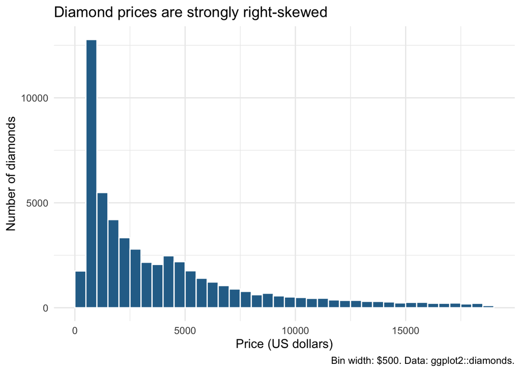

```r
price_histogram <- ggplot(diamonds_eda, aes(x = price)) +
  geom_histogram(binwidth = 500, boundary = 0, color = "white", fill = "#2A6F97") +
  labs(
    title = "Diamond prices are strongly right-skewed",
    x = "Price (US dollars)",
    y = "Number of diamonds",
    caption = "Bin width: $500. Data: ggplot2::diamonds."
  ) +
  theme_minimal(base_size = 12)

carat_price_plot <- ggplot(diamonds_eda, aes(x = carat, y = price)) +
  geom_point(alpha = 0.08, size = 0.7, color = "#264653") +
  labs(
    title = "Price generally increases with carat, with substantial variation",
    x = "Weight (carats)",
    y = "Price (US dollars)",
    caption = "Transparency reveals point density; the plot is descriptive, not causal."
  ) +
  theme_minimal(base_size = 12)

histogram_data <- ggplot_build(price_histogram)$data[[1]]
scatter_data <- ggplot_build(carat_price_plot)$data[[1]]

stopifnot(
  nrow(diamonds_eda) == 53940,
  ncol(diamonds_raw) == 10,
  ncol(diamonds_eda) == 11,
  sum(is.na(diamonds_eda)) == 0,
  sum(diamonds_eda$dimension_issue) == 20,
  nrow(cut_summary) == 5,
  sum(cut_summary$n_diamonds) == nrow(diamonds_eda),
  abs(sum(cut_summary$proportion) - 1) < 1e-12,
  nrow(price_by_cut) == 5,
  sum(price_by_cut$n_diamonds) == nrow(diamonds_eda),
  sum(histogram_data$count) == nrow(diamonds_eda),
  nrow(scatter_data) == nrow(diamonds_eda)
)

print(price_histogram)
```

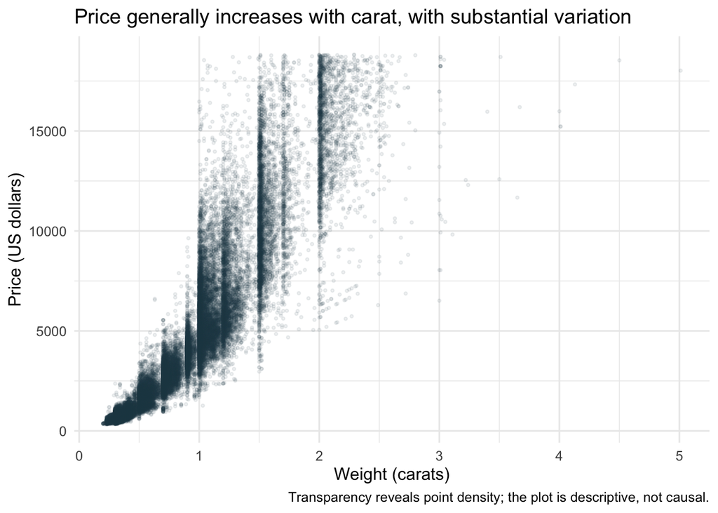

```r
print(carat_price_plot)
```

```r
cat("Rows with nonpositive dimensions:", nrow(dimension_issues), "\n")
```

```
Rows with nonpositive dimensions: 20
```

```r
cat("All Week 8 EDA checks passed.\n")
```

```
All Week 8 EDA checks passed.
```

**Explain / Check / Interpret:** The source checks 53,940 rows, no NA, twenty flagged rows, five cut groups and complete histogram/scatter counts. Anomaly causes are not established by those assertions. A zero dimension matters directly to a volume product; a carat-price plot uses other fields. Investigate the affected analysis rather than silently deleting all unusual records from every question.

### Meeting 1 in-class exit · Final five minutes

Record:

- one observed distribution pattern;
- one anomaly;
- one limitation;
- one next question.

Solo readers: use the self-check below; no submission.

### Meeting 1 self-check · No submission

Use the finding/anomaly/next-question activity: zero missing values and twenty nonpositive dimension records are reported. Name one investigation that would help a dimension-based calculation.

**Compare the Meeting 1 self-check**

Inspect the flagged source records and units, then compare the stated dimension-based result with and without the documented anomaly rule. Source verification is needed to explain the cause. Avoid declaring an error or silently dropping records merely because they are unusual.

## Meeting 2 · Check the claim

The same rows can support different displays with different strengths. Small transparent points reveal density better than large opaque marks. A boxplot compares price distributions across cut, but carat distributions also differ between cut groups. Inspecting related variables refines the descriptive question; it does not automatically isolate a causal effect.

### Compare displays and retain their limits

**Slide cues:** *Use Transparency*; *Check The Scatterplot Layer*; *Categorical And Quantitative*; *A Marginal Comparison Can Mislead*.

Read each plot as data + mappings + geometry + labels. The reference builds a histogram, cut bar chart, carat-price scatterplot and price-by-cut boxplot. `ggplot_build` exposes layer data: counts should reconcile, the scatter should contain all input rows, and category displays should represent all five cut levels.

The boxplot has one summary per category, not one row per diamond. The count check must match that geometry. A correct layer row count does not guarantee a readable design or a justified title. If you use a narrow carat range or facets in the selected lab, state the restriction and retained counts.

**Predict · Think first:** Should the boxplot layer and scatterplot layer each have 53,940 rows? What is the unit represented in each layer?

**Compare your reasoning**

The scatterplot has one point per diamond, so 53,940 layer rows. The boxplot layer summarizes five cut categories, so five rows. If your answer differed, you may have treated every geometry as a point-per-observation display. Check counts according to the layer’s actual meaning.

**Try before expanding:** Use Core 6 to compare opaque and transparent scatterplots with the same data. Read the mappings and units first, then run the plot checks.

**Reference version · week08-plot-checks_sol.R**

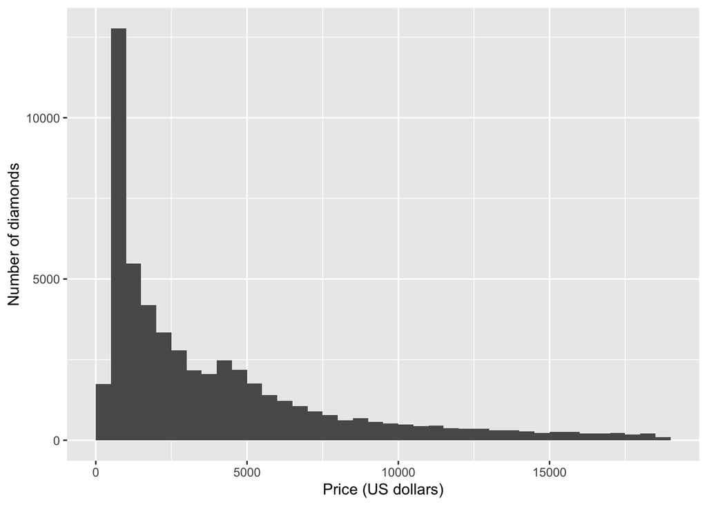

```r
# MATH 346 - possible worked solution
# Compare only after attempting the starter; other correct implementations are possible.

# MATH 346 - Week 8
# Distribution and covariation plots with executable data checks

library(dplyr)
library(ggplot2)

diamonds_eda <- diamonds |> as_tibble()

price_histogram <- ggplot(diamonds_eda, aes(x = price)) +
  geom_histogram(binwidth = 500, boundary = 0) +
  labs(x = "Price (US dollars)", y = "Number of diamonds")

cut_bar_plot <- ggplot(diamonds_eda, aes(x = cut)) +
  geom_bar() +
  labs(x = "Cut quality", y = "Number of diamonds")

carat_price_plot <- ggplot(diamonds_eda, aes(x = carat, y = price)) +
  geom_point(alpha = 0.08, size = 0.7) +
  labs(x = "Weight (carats)", y = "Price (US dollars)")

price_by_cut_plot <- ggplot(diamonds_eda, aes(x = cut, y = price)) +
  geom_boxplot(outlier.alpha = 0.15) +
  labs(x = "Cut quality", y = "Price (US dollars)")

histogram_data <- ggplot_build(price_histogram)$data[[1]]
bar_data <- ggplot_build(cut_bar_plot)$data[[1]]
scatter_data <- ggplot_build(carat_price_plot)$data[[1]]
boxplot_data <- ggplot_build(price_by_cut_plot)$data[[1]]

stopifnot(
  sum(histogram_data$count) == nrow(diamonds_eda),
  sum(bar_data$count) == nrow(diamonds_eda),
  nrow(bar_data) == nlevels(diamonds_eda$cut),
  nrow(scatter_data) == nrow(diamonds_eda),
  nrow(boxplot_data) == nlevels(diamonds_eda$cut),
  identical(carat_price_plot$labels$x, "Weight (carats)"),
  identical(carat_price_plot$labels$y, "Price (US dollars)")
)

print(price_histogram)
```

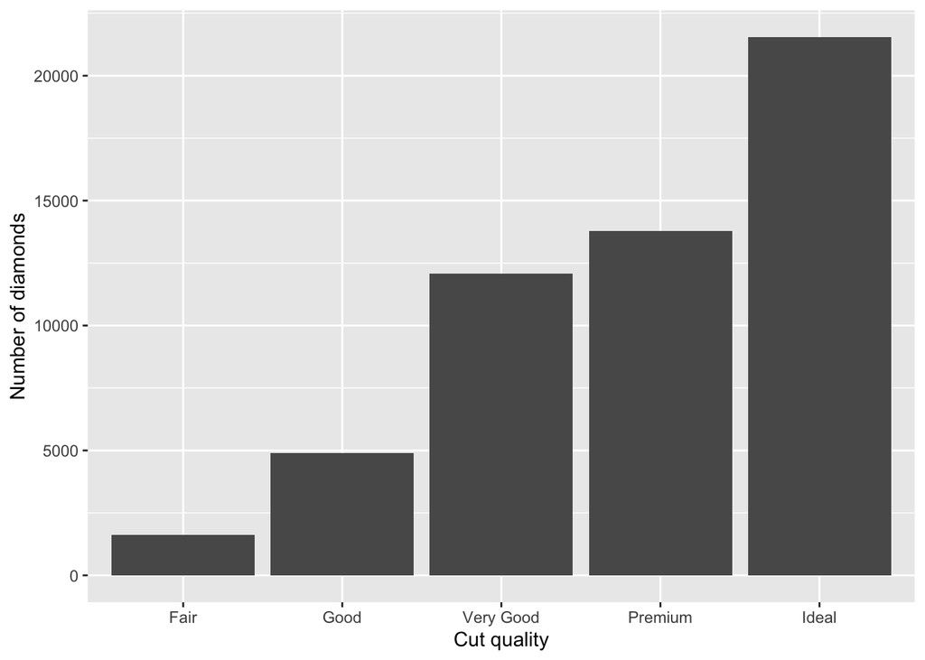

```r
print(cut_bar_plot)
```

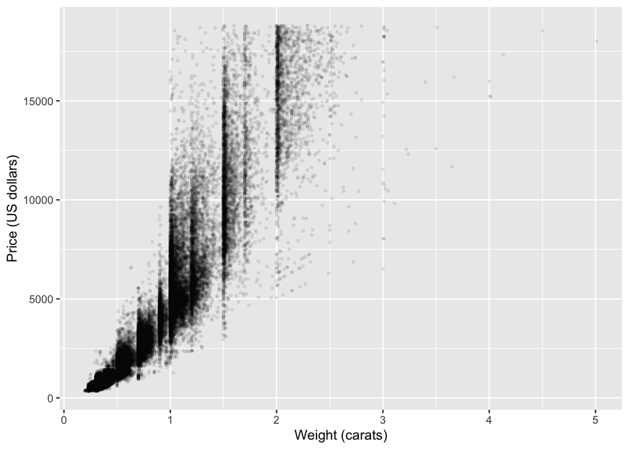

```r
print(carat_price_plot)
```

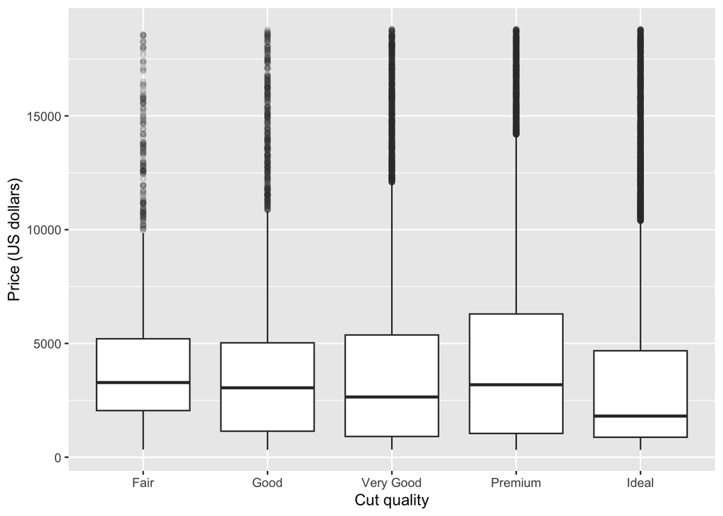

```r
print(price_by_cut_plot)
```

```r
cat("Histogram observations counted:", sum(histogram_data$count), "\n")
```

```
Histogram observations counted: 53940
```

```r
cat("Scatterplot observations checked:", nrow(scatter_data), "\n")
```

```
Scatterplot observations checked: 53940
```

```r
cat("All Week 8 plot checks passed.\n")
```

```
All Week 8 plot checks passed.
```

**Explain / Check / Interpret:** Keep two statements separate: larger-carat diamonds tend to have higher prices in these data; substantial price variation remains at similar weights. Price-by-cut differences can also reflect different carat distributions. The Guided conditional view can ask a better comparison without fitting a model. Put a next question and limitation beside the observed pattern.

## AI audit · Inspect before accepting

**Slide cues:** *Weak AI Plot*; *Weak AI Interpretation*; *AI Interpretation Audit*.

This section supports **Core 9**. Use its code-reading and checking steps for that exercise. The full AI-review lab is used only when selected.

Read the supplied target and choose a check before opening the diagnosis. No AI service is contacted.

Read the supplied plot and claim as separate objects. The mapping can be correct while opacity, units and causal wording are weak. Candidate checks: layer count, variation at similar carat values, cut-group carat distributions, and the dimension anomaly table. A count check cannot test causation.

**Reading excerpt:** this fragment relies on the supplied script setup; inspect it here, then run the complete file in the evidence reveal.

```r
generated_plot <- ggplot(diamonds, aes(x = carat, y = price)) +
  geom_point() +
  labs(
    title = "Carat determines diamond price",
    x = "Carat",
    y = "Price"
  )


generated_interpretation <- paste(
  "The plot proves that increasing carat causes price to rise by a fixed amount.",
  "All diamonds follow the same pattern, so cut, color, and clarity do not matter.",
  "There are no unusual observations or data-quality concerns."
)
```

**Predict in a private comment first:** Which parts of the generated explanation exceed a scatterplot’s evidence, even though its layer-count assertion passes?

**Compare your reasoning**

“Proves”, “causes”, a fixed increase, “all diamonds”, dismissal of other attributes and absence of anomalies are unsupported. Preserve an observed positive association, qualify variation and scope, and propose a conditional comparison. If your answer differed, you may have treated accurate plotting as validation of every sentence attached to the plot.

**Run the complete supplied critique target and inspect the evidence**

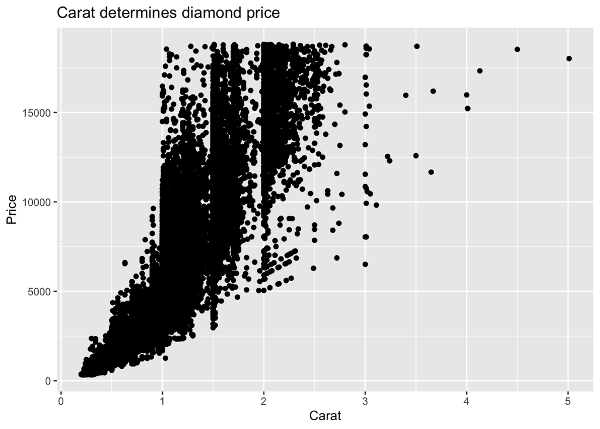

```r
# MATH 346 - Week 8
# AI interpretation critique starter
#
# The plot runs, but its design and the generated interpretation need review.

library(ggplot2)

generated_plot <- ggplot(diamonds, aes(x = carat, y = price)) +
  geom_point() +
  labs(
    title = "Carat determines diamond price",
    x = "Carat",
    y = "Price"
  )

print(generated_plot)
```

```r
generated_interpretation <- paste(
  "The plot proves that increasing carat causes price to rise by a fixed amount.",
  "All diamonds follow the same pattern, so cut, color, and clarity do not matter.",
  "There are no unusual observations or data-quality concerns."
)

cat(generated_interpretation, "\n")
```

```
The plot proves that increasing carat causes price to rise by a fixed amount. All diamonds follow the same pattern, so cut, color, and clarity do not matter. There are no unusual observations or data-quality concerns.
```

```r
plot_data <- ggplot_build(generated_plot)$data[[1]]
stopifnot(nrow(plot_data) == nrow(diamonds))

# Review questions:
# 1. Does a scatterplot establish causation or a fixed rate of change?
# 2. What variation remains among diamonds with similar carat values?
# 3. How does overplotting hide density in the generated figure?
# 4. Which additional variables might refine the question?
# 5. Do zero recorded dimensions or extreme measurements require inspection?
# 6. Which claims should be rewritten as observations, questions, or doubts?
```

Use the existing AI policy when assistance is used: explain every accepted line and keep the requested evidence with your existing work. A passing test never replaces checking whether the code answers the actual question.

### Meeting 2 in-class exit · Final five minutes

An exploratory pattern should become a finding, doubt, or next question when …

Solo readers: use the self-check below; no submission.

### Meeting 2 self-check · No submission

Close earlier reveals and explain from memory: An analyst sees a price difference between cut categories and says cut alone explains it. Which next check would improve this comparison, and what would still remain uncertain?

**Compare the Meeting 2 self-check**

Inspect carat distributions and compare prices among diamonds with similar carat, retaining group counts. Colour, clarity and selection can still differ, so this improves the descriptive comparison without proving cut caused the price difference. This is refinement, not a regression assignment.

## Practice, recovery and resources

**Core:** 1, 2, 3, 6, 9. **Guided:** 4, 5, 7. **Extension:** 8.

Core 1/2 classify and audit, Core 3 checks histogram choices, Core 6 compares scatterplot designs and Core 9 critiques claims. Guided 4/5/7 provide categorical, anomaly and conditional support; marginal-comparison Exercise 8 is Extension. Keep the original EDA-log practice within the selected lab, not as a second submission. Statistical models belong to Week 13.

Attempt the selected starter blocks before comparing possible solutions. TODO comments are placeholders, not completed analysis. Keep your checked script and follow Blackboard if a checkpoint is requested.

**If you are stuck:** inspect the plotted variables, geometry, bin width, and anomaly rule. Run missing definitions before their first use. Keep the first error and ask for help if a focused attempt remains blocked.

- Possible solution: week08-eda-cycle_sol.R
- Possible solution: week08-plot-checks_sol.R

**Where this fits:** [Week 8 notes](https://lnajman.github.io/math346/weeks/week-08.html) · [Matching slides](https://lnajman.github.io/math346/slides/week-08.html) · [Main lab](https://lnajman.github.io/math346/labs/lab-08-exploratory-data-analysis.html) · [AI-review lab](https://lnajman.github.io/math346/labs/lab-08-ai-interpretation-review.html) · [Exercises](https://lnajman.github.io/math346/weeks/week-08-exercises.html).